# 607_Project_2_1

Justin Hsi

3/5/2020

The goal of Project 2 is to choose wide/untidy datasets from Week 5 Discussion, ready from CSV into R to tidy/transform as needed, and perform the analysis requested in the discussion. I will start with my own Week 5 Discussion [here](https://bbhosted.cuny.edu/webapps/discussionboard/do/message?action=list_messages&course_id=_1838295_1&nav=discussion_board_entry&conf_id=_2012332_1&forum_id=_2105976_1&message_id=_36290919_1)

Read data from original repo and write csv.

```r
df = read_csv('https://raw.githubusercontent.com/jmhsi/DATA_607/master/Project%202/student_results.csv')
write.csv(df, 'student_results.csv', row.names=FALSE)
```

Load in data and tidy-up to long form

```r
df = read_csv('student_results.csv')
# split out "sex and age" into their own columns
df = df %>% separate('sex and age', into= c('sex', 'age'), sep = "_", remove = TRUE)
# turn "age" into a numeric col
df$age = as.numeric(df$age)
# clean "test number" col to just numeric
df$test_number = as.numeric(str_extract(df$'test number', '\\d'))
df = df %>% pivot_longer(cols = 7:9, names_to = 'term number', values_to ='score', values_drop_na = TRUE)
df$term_number = as.numeric(str_extract(df$'term number', '\\d'))
kable(df, caption='Tidied data')
```

Tidied data

| id | name | phone | sex | age | test number | test_number | term number | score | term_number |
| --- | --- | --- | --- | --- | --- | --- | --- | --- | --- |
| 1 | Mike | 134 | m | 12 | test 1 | 1 | term 1 | 76 | 1 |
| 1 | Mike | 134 | m | 12 | test 1 | 1 | term 2 | 84 | 2 |
| 1 | Mike | 134 | m | 12 | test 1 | 1 | term 3 | 87 | 3 |
| 2 | Linda | 270 | f | 13 | test 1 | 1 | term 1 | 88 | 1 |
| 2 | Linda | 270 | f | 13 | test 1 | 1 | term 2 | 90 | 2 |
| 2 | Linda | 270 | f | 13 | test 1 | 1 | term 3 | 73 | 3 |
| 3 | Sam | 210 | m | 11 | test 1 | 1 | term 1 | 78 | 1 |
| 3 | Sam | 210 | m | 11 | test 1 | 1 | term 2 | 74 | 2 |
| 3 | Sam | 210 | m | 11 | test 1 | 1 | term 3 | 80 | 3 |
| 4 | Esther | 617 | f | 12 | test 1 | 1 | term 1 | 68 | 1 |
| 4 | Esther | 617 | f | 12 | test 1 | 1 | term 2 | 75 | 2 |
| 4 | Esther | 617 | f | 12 | test 1 | 1 | term 3 | 74 | 3 |
| 5 | Mary | 114 | f | 14 | test 1 | 1 | term 1 | 65 | 1 |
| 5 | Mary | 114 | f | 14 | test 1 | 1 | term 2 | 67 | 2 |
| 5 | Mary | 114 | f | 14 | test 1 | 1 | term 3 | 64 | 3 |
| 1 | Mike | 134 | m | 12 | test 2 | 2 | term 1 | 85 | 1 |
| 1 | Mike | 134 | m | 12 | test 2 | 2 | term 2 | 80 | 2 |
| 1 | Mike | 134 | m | 12 | test 2 | 2 | term 3 | 90 | 3 |
| 2 | Linda | 270 | f | 13 | test 2 | 2 | term 1 | 87 | 1 |
| 2 | Linda | 270 | f | 13 | test 2 | 2 | term 2 | 82 | 2 |
| 2 | Linda | 270 | f | 13 | test 2 | 2 | term 3 | 94 | 3 |
| 3 | Sam | 210 | m | 11 | test 2 | 2 | term 1 | 80 | 1 |
| 3 | Sam | 210 | m | 11 | test 2 | 2 | term 2 | 87 | 2 |
| 3 | Sam | 210 | m | 11 | test 2 | 2 | term 3 | 80 | 3 |
| 4 | Esther | 617 | f | 12 | test 2 | 2 | term 1 | 70 | 1 |
| 4 | Esther | 617 | f | 12 | test 2 | 2 | term 2 | 75 | 2 |
| 4 | Esther | 617 | f | 12 | test 2 | 2 | term 3 | 78 | 3 |
| 5 | Mary | 114 | f | 14 | test 2 | 2 | term 1 | 68 | 1 |
| 5 | Mary | 114 | f | 14 | test 2 | 2 | term 2 | 70 | 2 |
| 5 | Mary | 114 | f | 14 | test 2 | 2 | term 3 | 63 | 3 |

Discussion questions: Which students are improving their performance on tests in later terms?

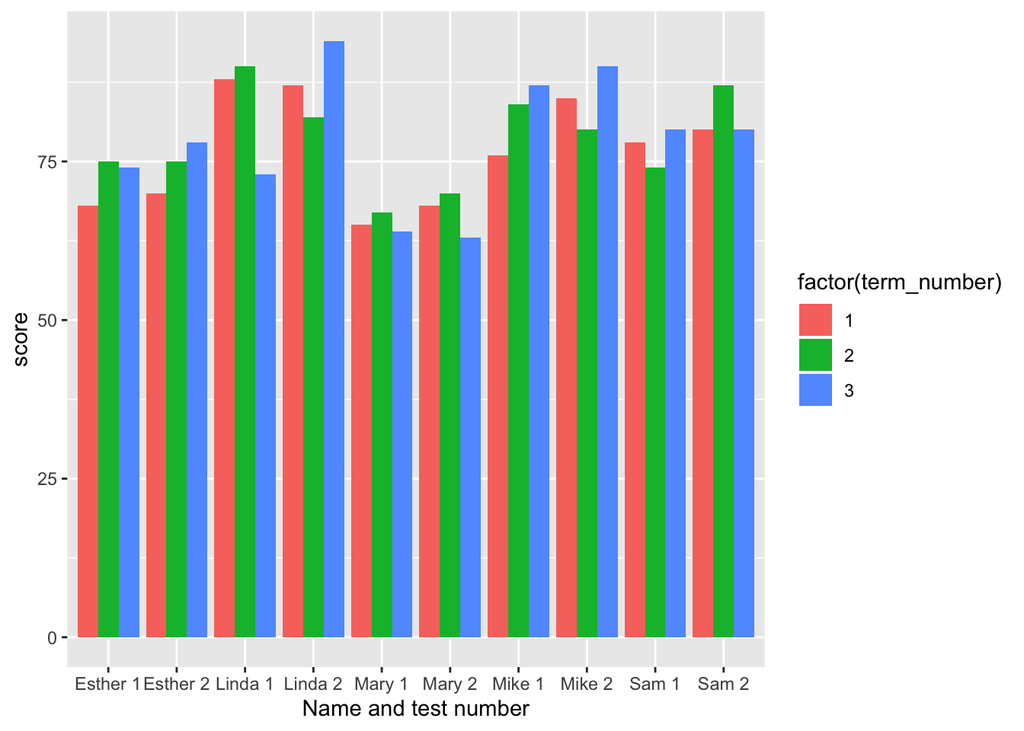

```r
df$name_testn = paste(df$name, df$test_number)
ggplot(df, aes(x = name_testn, y = score, fill=factor(term_number))) + geom_bar(stat = 'identity', position = 'dodge') + labs(x = 'Name and test number')
```

We see clear improvement over later terms for Esther on Test 2 and Mike on Test 1.Linda on Test 2, Mike on Test 2, and Sam on Test 1 all had the highest results in term 3 on that specific test, but their term 2 of that test was worse than their term 1.

Do gender and age seem to have any relationship with test performance?

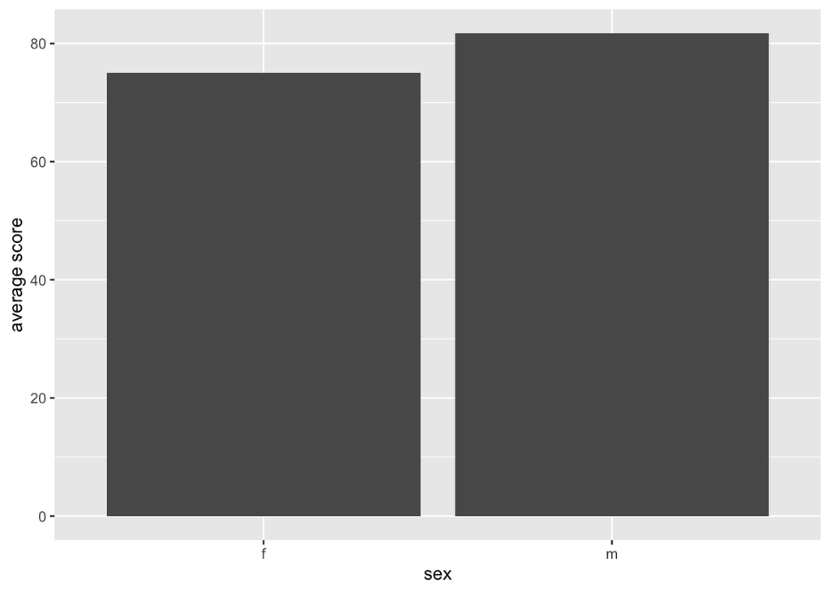

```r
# check gender
ggplot(aggregate(df[,9], list(df$sex), mean), aes(x = Group.1, y = score, )) + geom_bar(stat = 'identity', position = 'dodge') + labs(x = 'sex', y = 'average score')
```

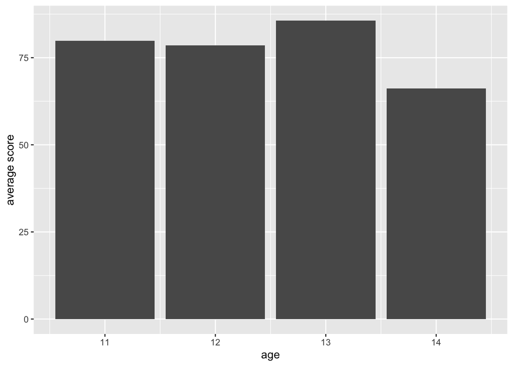

```r
# check age
ggplot(aggregate(df[,9], list(df$age), mean), aes(x = Group.1, y = score, )) + geom_bar(stat = 'identity', position = 'dodge') + labs(x = 'age', y = 'average score')
```